# Risk Factor Analysis

## Outcome Variable

**Outcome Variable:** sstunted

## Predictor Variables

**Intervention Variable:** hhwealth_quart

**Adjustment Set:**

unadjusted

## Stratifying Variables

The analysis was stratified on these variable(s):

- agecat
- studyid

The following strata were considered:

- agecat: 12 months, studyid: ki0047075b-MAL-ED
- agecat: 12 months, studyid: ki1000108-CMC-V-BCS-2002
- agecat: 12 months, studyid: ki1000108-IRC
- agecat: 12 months, studyid: ki1017093b-PROVIDE
- agecat: 12 months, studyid: ki1066203-TanzaniaChild2
- agecat: 12 months, studyid: ki1113344-GMS-Nepal
- agecat: 12 months, studyid: ki1114097-CONTENT
- agecat: 12 months, studyid: ki1135781-COHORTS
- agecat: 12 months, studyid: ki1148112-LCNI-5
- agecat: 18 months, studyid: ki0047075b-MAL-ED
- agecat: 18 months, studyid: ki1000108-CMC-V-BCS-2002
- agecat: 18 months, studyid: ki1000108-IRC
- agecat: 18 months, studyid: ki1017093b-PROVIDE
- agecat: 18 months, studyid: ki1066203-TanzaniaChild2
- agecat: 18 months, studyid: ki1113344-GMS-Nepal
- agecat: 18 months, studyid: ki1114097-CONTENT
- agecat: 18 months, studyid: ki1135781-COHORTS
- agecat: 18 months, studyid: ki1148112-LCNI-5
- agecat: 24 months, studyid: ki0047075b-MAL-ED
- agecat: 24 months, studyid: ki1000108-CMC-V-BCS-2002
- agecat: 24 months, studyid: ki1000108-IRC
- agecat: 24 months, studyid: ki1017093b-PROVIDE
- agecat: 24 months, studyid: ki1066203-TanzaniaChild2
- agecat: 24 months, studyid: ki1113344-GMS-Nepal
- agecat: 24 months, studyid: ki1114097-CONTENT
- agecat: 24 months, studyid: ki1135781-COHORTS
- agecat: 24 months, studyid: ki1148112-LCNI-5
- agecat: 3 months, studyid: ki0047075b-MAL-ED
- agecat: 3 months, studyid: ki1000108-CMC-V-BCS-2002
- agecat: 3 months, studyid: ki1000108-IRC
- agecat: 3 months, studyid: ki1017093b-PROVIDE
- agecat: 3 months, studyid: ki1066203-TanzaniaChild2
- agecat: 3 months, studyid: ki1113344-GMS-Nepal
- agecat: 3 months, studyid: ki1114097-CONTENT
- agecat: 3 months, studyid: ki1135781-COHORTS
- agecat: 6 months, studyid: ki0047075b-MAL-ED
- agecat: 6 months, studyid: ki1000108-CMC-V-BCS-2002
- agecat: 6 months, studyid: ki1000108-IRC
- agecat: 6 months, studyid: ki1017093b-PROVIDE
- agecat: 6 months, studyid: ki1066203-TanzaniaChild2
- agecat: 6 months, studyid: ki1113344-GMS-Nepal
- agecat: 6 months, studyid: ki1114097-CONTENT
- agecat: 6 months, studyid: ki1135781-COHORTS
- agecat: 6 months, studyid: ki1148112-LCNI-5
- agecat: 9 months, studyid: ki0047075b-MAL-ED
- agecat: 9 months, studyid: ki1000108-CMC-V-BCS-2002
- agecat: 9 months, studyid: ki1000108-IRC
- agecat: 9 months, studyid: ki1017093b-PROVIDE
- agecat: 9 months, studyid: ki1066203-TanzaniaChild2
- agecat: 9 months, studyid: ki1113344-GMS-Nepal
- agecat: 9 months, studyid: ki1114097-CONTENT
- agecat: 9 months, studyid: ki1135781-COHORTS
- agecat: 9 months, studyid: ki1148112-LCNI-5
- agecat: Birth, studyid: ki0047075b-MAL-ED
- agecat: Birth, studyid: ki1000108-CMC-V-BCS-2002
- agecat: Birth, studyid: ki1000108-IRC
- agecat: Birth, studyid: ki1114097-CONTENT
- agecat: Birth, studyid: ki1135781-COHORTS

### Dropped Strata

Some strata were dropped due to rare outcomes:

- agecat: Birth, studyid: ki0047075b-MAL-ED
- agecat: Birth, studyid: ki1000108-CMC-V-BCS-2002
- agecat: Birth, studyid: ki1000108-IRC
- agecat: Birth, studyid: ki1114097-CONTENT
- agecat: 3 months, studyid: ki0047075b-MAL-ED
- agecat: 3 months, studyid: ki1017093b-PROVIDE
- agecat: 3 months, studyid: ki1066203-TanzaniaChild2
- agecat: 3 months, studyid: ki1113344-GMS-Nepal
- agecat: 3 months, studyid: ki1114097-CONTENT
- agecat: 6 months, studyid: ki0047075b-MAL-ED
- agecat: 6 months, studyid: ki1000108-CMC-V-BCS-2002
- agecat: 6 months, studyid: ki1000108-IRC
- agecat: 6 months, studyid: ki1017093b-PROVIDE
- agecat: 6 months, studyid: ki1066203-TanzaniaChild2
- agecat: 6 months, studyid: ki1113344-GMS-Nepal
- agecat: 6 months, studyid: ki1114097-CONTENT
- agecat: 9 months, studyid: ki0047075b-MAL-ED
- agecat: 9 months, studyid: ki1000108-CMC-V-BCS-2002
- agecat: 9 months, studyid: ki1017093b-PROVIDE
- agecat: 9 months, studyid: ki1066203-TanzaniaChild2
- agecat: 9 months, studyid: ki1114097-CONTENT
- agecat: 9 months, studyid: ki1148112-LCNI-5
- agecat: 12 months, studyid: ki1017093b-PROVIDE
- agecat: 12 months, studyid: ki1066203-TanzaniaChild2
- agecat: 12 months, studyid: ki1114097-CONTENT
- agecat: 18 months, studyid: ki1017093b-PROVIDE
- agecat: 18 months, studyid: ki1066203-TanzaniaChild2
- agecat: 18 months, studyid: ki1114097-CONTENT
- agecat: 24 months, studyid: ki1017093b-PROVIDE
- agecat: 24 months, studyid: ki1066203-TanzaniaChild2
- agecat: 24 months, studyid: ki1114097-CONTENT
- agecat: 24 months, studyid: ki1148112-LCNI-5

## Methods Detail

We’re interested in the causal parameters $E[Y_a]$ for all values of $a \in \mathcal{A}$. These parameters represent the mean outcome if, possibly contrary to fact, we intervened to set all units to have $A=a$. Under the randomization and positivity assumptions, these are identified by the statistical parameters $\psi_a=E_W[E_{Y|A,W}(Y|A=a,W)]$. In addition, we’re interested in the mean of $Y$, $E[Y]$ under no intervention (the observed mean). We will estimate these parameters by using SuperLearner to fit the relevant likelihood factors – $E_{Y|A,W}(Y|A=a,W)$ and $p(A=a|W)$, and then updating our likelihood fit using a joint TMLE.

For unadjusted analyses ($W=\{\}$), initial likelihoods were estimated using Lrnr_glm to estimate the simple $E(Y|A)$ and Lrnr_mean to estimate $p(A)$. For adjusted analyses, a small library containing Lrnr_glmnet, Lrnr_xgboost, and Lrnr_mean was used.

Having estimated these parameters, we will then use the delta method to estimate relative risks and attributable risks relative to a prespecified baseline level of $A$.

# Results Detail

## Results Plots

[figure not shown]

[figure not shown]

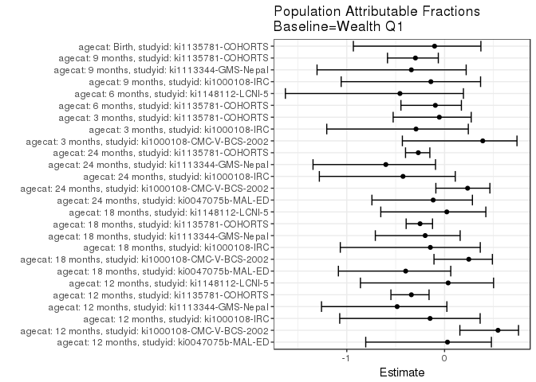

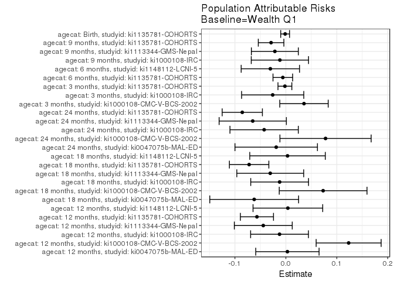

## Data Summary

| agecat | studyid | A | n | nA | nAY0 | nAY1 |
| --- | --- | --- | --- | --- | --- | --- |
| Birth | ki0047075b-MAL-ED | Wealth Q1 | 291 | 65 | 65 | 0 |
| Birth | ki0047075b-MAL-ED | Wealth Q2 | 291 | 69 | 67 | 2 |
| Birth | ki0047075b-MAL-ED | Wealth Q3 | 291 | 81 | 78 | 3 |
| Birth | ki0047075b-MAL-ED | Wealth Q4 | 291 | 76 | 73 | 3 |
| Birth | ki1000108-CMC-V-BCS-2002 | Wealth Q1 | 90 | 14 | 14 | 0 |
| Birth | ki1000108-CMC-V-BCS-2002 | Wealth Q2 | 90 | 20 | 19 | 1 |
| Birth | ki1000108-CMC-V-BCS-2002 | Wealth Q3 | 90 | 25 | 23 | 2 |
| Birth | ki1000108-CMC-V-BCS-2002 | Wealth Q4 | 90 | 31 | 31 | 0 |
| Birth | ki1000108-IRC | Wealth Q1 | 388 | 98 | 96 | 2 |
| Birth | ki1000108-IRC | Wealth Q2 | 388 | 99 | 92 | 7 |
| Birth | ki1000108-IRC | Wealth Q3 | 388 | 100 | 97 | 3 |
| Birth | ki1000108-IRC | Wealth Q4 | 388 | 91 | 87 | 4 |
| Birth | ki1017093b-PROVIDE | Wealth Q1 | 0 | 0 | 0 | 0 |
| Birth | ki1017093b-PROVIDE | Wealth Q2 | 0 | 0 | 0 | 0 |
| Birth | ki1017093b-PROVIDE | Wealth Q3 | 0 | 0 | 0 | 0 |
| Birth | ki1017093b-PROVIDE | Wealth Q4 | 0 | 0 | 0 | 0 |
| Birth | ki1066203-TanzaniaChild2 | Wealth Q1 | 0 | 0 | 0 | 0 |
| Birth | ki1066203-TanzaniaChild2 | Wealth Q2 | 0 | 0 | 0 | 0 |
| Birth | ki1066203-TanzaniaChild2 | Wealth Q3 | 0 | 0 | 0 | 0 |
| Birth | ki1066203-TanzaniaChild2 | Wealth Q4 | 0 | 0 | 0 | 0 |
| Birth | ki1113344-GMS-Nepal | Wealth Q1 | 0 | 0 | 0 | 0 |
| Birth | ki1113344-GMS-Nepal | Wealth Q2 | 0 | 0 | 0 | 0 |
| Birth | ki1113344-GMS-Nepal | Wealth Q3 | 0 | 0 | 0 | 0 |
| Birth | ki1113344-GMS-Nepal | Wealth Q4 | 0 | 0 | 0 | 0 |
| Birth | ki1114097-CONTENT | Wealth Q1 | 2 | 0 | 0 | 0 |
| Birth | ki1114097-CONTENT | Wealth Q2 | 2 | 1 | 1 | 0 |
| Birth | ki1114097-CONTENT | Wealth Q3 | 2 | 1 | 1 | 0 |
| Birth | ki1114097-CONTENT | Wealth Q4 | 2 | 0 | 0 | 0 |
| Birth | ki1135781-COHORTS | Wealth Q1 | 3430 | 778 | 766 | 12 |
| Birth | ki1135781-COHORTS | Wealth Q2 | 3430 | 602 | 587 | 15 |

[output cut: 222 more lines]

## Results Table

### Parameter: TSM

| agecat | studyid | intervention_level | baseline_level | estimate | ci_lower | ci_upper |
| --- | --- | --- | --- | --- | --- | --- |
| Birth | ki1135781-COHORTS | Wealth Q1 | NA | 0.0154242 | 0.0067636 | 0.0240847 |
| Birth | ki1135781-COHORTS | Wealth Q2 | NA | 0.0249169 | 0.0124637 | 0.0373702 |
| Birth | ki1135781-COHORTS | Wealth Q3 | NA | 0.0131579 | 0.0063100 | 0.0200058 |
| Birth | ki1135781-COHORTS | Wealth Q4 | NA | 0.0070994 | 0.0018581 | 0.0123407 |
| 3 months | ki1000108-CMC-V-BCS-2002 | Wealth Q1 | NA | 0.0555556 | 0.0081663 | 0.1029448 |
| 3 months | ki1000108-CMC-V-BCS-2002 | Wealth Q2 | NA | 0.0760870 | 0.0218337 | 0.1303402 |
| 3 months | ki1000108-CMC-V-BCS-2002 | Wealth Q3 | NA | 0.0804598 | 0.0232245 | 0.1376951 |
| 3 months | ki1000108-CMC-V-BCS-2002 | Wealth Q4 | NA | 0.1505376 | 0.0777593 | 0.2233159 |
| 3 months | ki1000108-IRC | Wealth Q1 | NA | 0.1142857 | 0.0533558 | 0.1752156 |
| 3 months | ki1000108-IRC | Wealth Q2 | NA | 0.1287129 | 0.0633226 | 0.1941032 |
| 3 months | ki1000108-IRC | Wealth Q3 | NA | 0.0582524 | 0.0129639 | 0.1035409 |
| 3 months | ki1000108-IRC | Wealth Q4 | NA | 0.0510204 | 0.0074020 | 0.0946388 |
| 3 months | ki1135781-COHORTS | Wealth Q1 | NA | 0.0367347 | 0.0231334 | 0.0503360 |
| 3 months | ki1135781-COHORTS | Wealth Q2 | NA | 0.0320405 | 0.0178641 | 0.0462168 |
| 3 months | ki1135781-COHORTS | Wealth Q3 | NA | 0.0405797 | 0.0285570 | 0.0526024 |
| 3 months | ki1135781-COHORTS | Wealth Q4 | NA | 0.0290456 | 0.0184430 | 0.0396483 |
| 6 months | ki1135781-COHORTS | Wealth Q1 | NA | 0.0691729 | 0.0498840 | 0.0884619 |
| 6 months | ki1135781-COHORTS | Wealth Q2 | NA | 0.0738137 | 0.0523266 | 0.0953008 |
| 6 months | ki1135781-COHORTS | Wealth Q3 | NA | 0.0719281 | 0.0559200 | 0.0879362 |
| 6 months | ki1135781-COHORTS | Wealth Q4 | NA | 0.0427163 | 0.0295974 | 0.0558353 |
| 6 months | ki1148112-LCNI-5 | Wealth Q1 | NA | 0.0970874 | 0.0398380 | 0.1543367 |
| 6 months | ki1148112-LCNI-5 | Wealth Q2 | NA | 0.0526316 | 0.0076737 | 0.0975895 |
| 6 months | ki1148112-LCNI-5 | Wealth Q3 | NA | 0.0526316 | 0.0076737 | 0.0975895 |
| 6 months | ki1148112-LCNI-5 | Wealth Q4 | NA | 0.0625000 | 0.0176150 | 0.1073850 |
| 9 months | ki1000108-IRC | Wealth Q1 | NA | 0.0952381 | 0.0390221 | 0.1514541 |
| 9 months | ki1000108-IRC | Wealth Q2 | NA | 0.0900000 | 0.0338404 | 0.1461596 |
| 9 months | ki1000108-IRC | Wealth Q3 | NA | 0.0679612 | 0.0192968 | 0.1166255 |
| 9 months | ki1000108-IRC | Wealth Q4 | NA | 0.0808081 | 0.0270560 | 0.1345601 |
| 9 months | ki1113344-GMS-Nepal | Wealth Q1 | NA | 0.0851064 | 0.0390065 | 0.1312062 |
| 9 months | ki1113344-GMS-Nepal | Wealth Q2 | NA | 0.0719424 | 0.0289477 | 0.1149372 |

[output cut: 74 more lines]

### Parameter: E(Y)

| agecat | studyid | intervention_level | baseline_level | estimate | ci_lower | ci_upper |
| --- | --- | --- | --- | --- | --- | --- |
| Birth | ki1135781-COHORTS | NA | NA | 0.0139942 | 0.0137953 | 0.0141930 |
| 3 months | ki1000108-CMC-V-BCS-2002 | NA | NA | 0.0911602 | 0.0874320 | 0.0948884 |
| 3 months | ki1000108-IRC | NA | NA | 0.0884521 | 0.0851641 | 0.0917401 |
| 3 months | ki1135781-COHORTS | NA | NA | 0.0348662 | 0.0347062 | 0.0350263 |
| 6 months | ki1135781-COHORTS | NA | NA | 0.0632147 | 0.0627541 | 0.0636754 |
| 6 months | ki1148112-LCNI-5 | NA | NA | 0.0666667 | 0.0648884 | 0.0684449 |
| 9 months | ki1000108-IRC | NA | NA | 0.0835381 | 0.0825235 | 0.0845527 |
| 9 months | ki1113344-GMS-Nepal | NA | NA | 0.0635209 | 0.0620012 | 0.0650405 |
| 9 months | ki1135781-COHORTS | NA | NA | 0.0972973 | 0.0965773 | 0.0980173 |
| 12 months | ki0047075b-MAL-ED | NA | NA | 0.1030641 | 0.0998661 | 0.1062620 |
| 12 months | ki1000108-CMC-V-BCS-2002 | NA | NA | 0.2255435 | 0.2184295 | 0.2326575 |
| 12 months | ki1000108-IRC | NA | NA | 0.0837438 | 0.0817585 | 0.0857292 |
| 12 months | ki1113344-GMS-Nepal | NA | NA | 0.0913978 | 0.0887936 | 0.0940021 |
| 12 months | ki1135781-COHORTS | NA | NA | 0.1672067 | 0.1660181 | 0.1683954 |
| 12 months | ki1148112-LCNI-5 | NA | NA | 0.1078431 | 0.1038022 | 0.1118840 |
| 18 months | ki0047075b-MAL-ED | NA | NA | 0.1562500 | 0.1496849 | 0.1628151 |
| 18 months | ki1000108-CMC-V-BCS-2002 | NA | NA | 0.2953930 | 0.2906989 | 0.3000870 |
| 18 months | ki1000108-IRC | NA | NA | 0.0839506 | 0.0830436 | 0.0848576 |
| 18 months | ki1113344-GMS-Nepal | NA | NA | 0.1545455 | 0.1520853 | 0.1570056 |
| 18 months | ki1135781-COHORTS | NA | NA | 0.2876759 | 0.2857143 | 0.2896375 |
| 18 months | ki1148112-LCNI-5 | NA | NA | 0.1444759 | 0.1423270 | 0.1466249 |
| 24 months | ki0047075b-MAL-ED | NA | NA | 0.1628571 | 0.1567144 | 0.1689998 |
| 24 months | ki1000108-CMC-V-BCS-2002 | NA | NA | 0.3306452 | 0.3258983 | 0.3353920 |
| 24 months | ki1000108-IRC | NA | NA | 0.1002445 | 0.0970342 | 0.1034548 |
| 24 months | ki1113344-GMS-Nepal | NA | NA | 0.1082164 | 0.1044275 | 0.1120053 |
| 24 months | ki1135781-COHORTS | NA | NA | 0.3181509 | 0.3155844 | 0.3207174 |

### Parameter: RR

| agecat | studyid | intervention_level | baseline_level | estimate | ci_lower | ci_upper |
| --- | --- | --- | --- | --- | --- | --- |
| Birth | ki1135781-COHORTS | Wealth Q2 | Wealth Q1 | 1.6154485 | 0.7617817 | 3.4257504 |
| Birth | ki1135781-COHORTS | Wealth Q3 | Wealth Q1 | 0.8530702 | 0.3967267 | 1.8343325 |
| Birth | ki1135781-COHORTS | Wealth Q4 | Wealth Q1 | 0.4602772 | 0.1820525 | 1.1637032 |
| 3 months | ki1000108-CMC-V-BCS-2002 | Wealth Q2 | Wealth Q1 | 1.3695652 | 0.4505511 | 4.1631433 |
| 3 months | ki1000108-CMC-V-BCS-2002 | Wealth Q3 | Wealth Q1 | 1.4482759 | 0.4769610 | 4.3976403 |
| 3 months | ki1000108-CMC-V-BCS-2002 | Wealth Q4 | Wealth Q1 | 2.7096774 | 1.0164801 | 7.2233106 |
| 3 months | ki1000108-IRC | Wealth Q2 | Wealth Q1 | 1.1262376 | 0.5392646 | 2.3521129 |
| 3 months | ki1000108-IRC | Wealth Q3 | Wealth Q1 | 0.5097087 | 0.1985713 | 1.3083615 |
| 3 months | ki1000108-IRC | Wealth Q4 | Wealth Q1 | 0.4464286 | 0.1629993 | 1.2226952 |
| 3 months | ki1135781-COHORTS | Wealth Q2 | Wealth Q1 | 0.8722129 | 0.4898497 | 1.5530381 |
| 3 months | ki1135781-COHORTS | Wealth Q3 | Wealth Q1 | 1.1046699 | 0.6875250 | 1.7749109 |
| 3 months | ki1135781-COHORTS | Wealth Q4 | Wealth Q1 | 0.7906870 | 0.4701063 | 1.3298820 |
| 6 months | ki1135781-COHORTS | Wealth Q2 | Wealth Q1 | 1.0670895 | 0.7130709 | 1.5968677 |
| 6 months | ki1135781-COHORTS | Wealth Q3 | Wealth Q1 | 1.0398297 | 0.7278066 | 1.4856225 |
| 6 months | ki1135781-COHORTS | Wealth Q4 | Wealth Q1 | 0.6175294 | 0.4078511 | 0.9350045 |
| 6 months | ki1148112-LCNI-5 | Wealth Q2 | Wealth Q1 | 0.5421053 | 0.1920005 | 1.5306113 |
| 6 months | ki1148112-LCNI-5 | Wealth Q3 | Wealth Q1 | 0.5421053 | 0.1920005 | 1.5306113 |
| 6 months | ki1148112-LCNI-5 | Wealth Q4 | Wealth Q1 | 0.6437500 | 0.2541903 | 1.6303299 |
| 9 months | ki1000108-IRC | Wealth Q2 | Wealth Q1 | 0.9450000 | 0.4003100 | 2.2308333 |
| 9 months | ki1000108-IRC | Wealth Q3 | Wealth Q1 | 0.7135922 | 0.2821177 | 1.8049697 |
| 9 months | ki1000108-IRC | Wealth Q4 | Wealth Q1 | 0.8484848 | 0.3486735 | 2.0647585 |
| 9 months | ki1113344-GMS-Nepal | Wealth Q2 | Wealth Q1 | 0.8453237 | 0.3773383 | 1.8937178 |
| 9 months | ki1113344-GMS-Nepal | Wealth Q3 | Wealth Q1 | 0.7121212 | 0.3003458 | 1.6884423 |
| 9 months | ki1113344-GMS-Nepal | Wealth Q4 | Wealth Q1 | 0.4226619 | 0.1527833 | 1.1692576 |
| 9 months | ki1135781-COHORTS | Wealth Q2 | Wealth Q1 | 0.8099180 | 0.5913047 | 1.1093556 |
| 9 months | ki1135781-COHORTS | Wealth Q3 | Wealth Q1 | 0.7997623 | 0.6092357 | 1.0498725 |
| 9 months | ki1135781-COHORTS | Wealth Q4 | Wealth Q1 | 0.5451495 | 0.3997135 | 0.7435024 |
| 12 months | ki0047075b-MAL-ED | Wealth Q2 | Wealth Q1 | 1.3636364 | 0.6042535 | 3.0773575 |
| 12 months | ki0047075b-MAL-ED | Wealth Q3 | Wealth Q1 | 1.2222222 | 0.5317591 | 2.8092180 |
| 12 months | ki0047075b-MAL-ED | Wealth Q4 | Wealth Q1 | 0.5494506 | 0.1912873 | 1.5782327 |
| 12 months | ki1000108-CMC-V-BCS-2002 | Wealth Q2 | Wealth Q1 | 2.4701754 | 1.2143874 | 5.0245636 |
| 12 months | ki1000108-CMC-V-BCS-2002 | Wealth Q3 | Wealth Q1 | 2.6074074 | 1.2838905 | 5.2952905 |
| 12 months | ki1000108-CMC-V-BCS-2002 | Wealth Q4 | Wealth Q1 | 2.6760234 | 1.3271450 | 5.3958694 |
| 12 months | ki1000108-IRC | Wealth Q2 | Wealth Q1 | 1.1440000 | 0.5078075 | 2.5772286 |
| 12 months | ki1000108-IRC | Wealth Q3 | Wealth Q1 | 0.6058252 | 0.2282929 | 1.6076902 |
| 12 months | ki1000108-IRC | Wealth Q4 | Wealth Q1 | 0.7353535 | 0.2910123 | 1.8581508 |
| 12 months | ki1113344-GMS-Nepal | Wealth Q2 | Wealth Q1 | 0.7316163 | 0.3818943 | 1.4015982 |
| 12 months | ki1113344-GMS-Nepal | Wealth Q3 | Wealth Q1 | 0.6003899 | 0.2967891 | 1.2145592 |
| 12 months | ki1113344-GMS-Nepal | Wealth Q4 | Wealth Q1 | 0.3632320 | 0.1575503 | 0.8374308 |
| 12 months | ki1135781-COHORTS | Wealth Q2 | Wealth Q1 | 0.7307478 | 0.5763745 | 0.9264677 |
| 12 months | ki1135781-COHORTS | Wealth Q3 | Wealth Q1 | 0.7587827 | 0.6205433 | 0.9278180 |
| 12 months | ki1135781-COHORTS | Wealth Q4 | Wealth Q1 | 0.5706873 | 0.4571954 | 0.7123517 |
| 12 months | ki1148112-LCNI-5 | Wealth Q2 | Wealth Q1 | 0.9314516 | 0.3406378 | 2.5469932 |
| 12 months | ki1148112-LCNI-5 | Wealth Q3 | Wealth Q1 | 0.6091772 | 0.2080943 | 1.7833112 |
| 12 months | ki1148112-LCNI-5 | Wealth Q4 | Wealth Q1 | 1.5312500 | 0.6782190 | 3.4571821 |
| 18 months | ki0047075b-MAL-ED | Wealth Q2 | Wealth Q1 | 0.8421053 | 0.4641044 | 1.5279779 |
| 18 months | ki0047075b-MAL-ED | Wealth Q3 | Wealth Q1 | 0.7986536 | 0.4345160 | 1.4679496 |
| 18 months | ki0047075b-MAL-ED | Wealth Q4 | Wealth Q1 | 0.2488558 | 0.0970302 | 0.6382469 |
| 18 months | ki1000108-CMC-V-BCS-2002 | Wealth Q2 | Wealth Q1 | 1.5483871 | 0.9597678 | 2.4980027 |
| 18 months | ki1000108-CMC-V-BCS-2002 | Wealth Q3 | Wealth Q1 | 1.3000000 | 0.7844624 | 2.1543415 |
| 18 months | ki1000108-CMC-V-BCS-2002 | Wealth Q4 | Wealth Q1 | 1.4531250 | 0.8958848 | 2.3569685 |
| 18 months | ki1000108-IRC | Wealth Q2 | Wealth Q1 | 0.8404040 | 0.3454194 | 2.0446997 |
| 18 months | ki1000108-IRC | Wealth Q3 | Wealth Q1 | 0.9087379 | 0.3847749 | 2.1462018 |
| 18 months | ki1000108-IRC | Wealth Q4 | Wealth Q1 | 0.7353535 | 0.2910115 | 1.8581561 |
| 18 months | ki1113344-GMS-Nepal | Wealth Q2 | Wealth Q1 | 0.7328571 | 0.4235954 | 1.2679070 |
| 18 months | ki1113344-GMS-Nepal | Wealth Q3 | Wealth Q1 | 0.9893130 | 0.5962412 | 1.6415172 |
| 18 months | ki1113344-GMS-Nepal | Wealth Q4 | Wealth Q1 | 0.6375000 | 0.3604638 | 1.1274537 |
| 18 months | ki1135781-COHORTS | Wealth Q2 | Wealth Q1 | 0.8867942 | 0.7512702 | 1.0467657 |
| 18 months | ki1135781-COHORTS | Wealth Q3 | Wealth Q1 | 0.8199362 | 0.7080846 | 0.9494563 |
| 18 months | ki1135781-COHORTS | Wealth Q4 | Wealth Q1 | 0.5935545 | 0.5027923 | 0.7007009 |
| 18 months | ki1148112-LCNI-5 | Wealth Q2 | Wealth Q1 | 1.2500000 | 0.6219709 | 2.5121755 |
| 18 months | ki1148112-LCNI-5 | Wealth Q3 | Wealth Q1 | 0.8333333 | 0.3802453 | 1.8263066 |
| 18 months | ki1148112-LCNI-5 | Wealth Q4 | Wealth Q1 | 1.0119048 | 0.4948970 | 2.0690191 |
| 24 months | ki0047075b-MAL-ED | Wealth Q2 | Wealth Q1 | 1.3095238 | 0.7285869 | 2.3536693 |
| 24 months | ki0047075b-MAL-ED | Wealth Q3 | Wealth Q1 | 0.8953488 | 0.4656664 | 1.7215104 |
| 24 months | ki0047075b-MAL-ED | Wealth Q4 | Wealth Q1 | 0.4184783 | 0.1806745 | 0.9692793 |
| 24 months | ki1000108-CMC-V-BCS-2002 | Wealth Q2 | Wealth Q1 | 1.4993135 | 0.9678242 | 2.3226749 |
| 24 months | ki1000108-CMC-V-BCS-2002 | Wealth Q3 | Wealth Q1 | 1.3478261 | 0.8550861 | 2.1245055 |
| 24 months | ki1000108-CMC-V-BCS-2002 | Wealth Q4 | Wealth Q1 | 1.3743707 | 0.8774901 | 2.1526110 |
| 24 months | ki1000108-IRC | Wealth Q2 | Wealth Q1 | 0.6930693 | 0.3264019 | 1.4716369 |
| 24 months | ki1000108-IRC | Wealth Q3 | Wealth Q1 | 0.7475728 | 0.3603010 | 1.5511063 |
| 24 months | ki1000108-IRC | Wealth Q4 | Wealth Q1 | 0.3500000 | 0.1319435 | 0.9284277 |
| 24 months | ki1113344-GMS-Nepal | Wealth Q2 | Wealth Q1 | 0.6872294 | 0.3738308 | 1.2633638 |
| 24 months | ki1113344-GMS-Nepal | Wealth Q3 | Wealth Q1 | 0.3880825 | 0.1796226 | 0.8384693 |
| 24 months | ki1113344-GMS-Nepal | Wealth Q4 | Wealth Q1 | 0.4090909 | 0.1959206 | 0.8541998 |
| 24 months | ki1135781-COHORTS | Wealth Q2 | Wealth Q1 | 0.9307318 | 0.8029456 | 1.0788547 |
| 24 months | ki1135781-COHORTS | Wealth Q3 | Wealth Q1 | 0.8071407 | 0.7057219 | 0.9231343 |
| 24 months | ki1135781-COHORTS | Wealth Q4 | Wealth Q1 | 0.5437032 | 0.4644660 | 0.6364582 |

### Parameter: PAR

| agecat | studyid | intervention_level | baseline_level | estimate | ci_lower | ci_upper |
| --- | --- | --- | --- | --- | --- | --- |
| Birth | ki1135781-COHORTS | Wealth Q1 | NA | -0.0014300 | -0.0100929 | 0.0072329 |
| 3 months | ki1000108-CMC-V-BCS-2002 | Wealth Q1 | NA | 0.0356047 | -0.0119310 | 0.0831403 |
| 3 months | ki1000108-IRC | Wealth Q1 | NA | -0.0258336 | -0.0868522 | 0.0351849 |
| 3 months | ki1135781-COHORTS | Wealth Q1 | NA | -0.0018684 | -0.0154707 | 0.0117338 |
| 6 months | ki1135781-COHORTS | Wealth Q1 | NA | -0.0059582 | -0.0252527 | 0.0133363 |
| 6 months | ki1148112-LCNI-5 | Wealth Q1 | NA | -0.0304207 | -0.0876977 | 0.0268562 |
| 9 months | ki1000108-IRC | Wealth Q1 | NA | -0.0117000 | -0.0679252 | 0.0445252 |
| 9 months | ki1113344-GMS-Nepal | Wealth Q1 | NA | -0.0215855 | -0.0677104 | 0.0245394 |
| 9 months | ki1135781-COHORTS | Wealth Q1 | NA | -0.0290029 | -0.0541143 | -0.0038914 |
| 12 months | ki0047075b-MAL-ED | Wealth Q1 | NA | 0.0030641 | -0.0590843 | 0.0652124 |
| 12 months | ki1000108-CMC-V-BCS-2002 | Wealth Q1 | NA | 0.1232708 | 0.0594786 | 0.1870629 |
| 12 months | ki1000108-IRC | Wealth Q1 | NA | -0.0124100 | -0.0691727 | 0.0443527 |
| 12 months | ki1113344-GMS-Nepal | Wealth Q1 | NA | -0.0443164 | -0.1011587 | 0.0125258 |
| 12 months | ki1135781-COHORTS | Wealth Q1 | NA | -0.0567680 | -0.0892470 | -0.0242890 |
| 12 months | ki1148112-LCNI-5 | Wealth Q1 | NA | 0.0039470 | -0.0644366 | 0.0723306 |
| 18 months | ki0047075b-MAL-ED | Wealth Q1 | NA | -0.0621408 | -0.1493280 | 0.0250464 |
| 18 months | ki1000108-CMC-V-BCS-2002 | Wealth Q1 | NA | 0.0731707 | -0.0129650 | 0.1593065 |
| 18 months | ki1000108-IRC | Wealth Q1 | NA | -0.0122032 | -0.0689387 | 0.0445322 |
| 18 months | ki1113344-GMS-Nepal | Wealth Q1 | NA | -0.0306397 | -0.0962715 | 0.0349921 |
| 18 months | ki1135781-COHORTS | Wealth Q1 | NA | -0.0721214 | -0.1108389 | -0.0334038 |
| 18 months | ki1148112-LCNI-5 | Wealth Q1 | NA | 0.0032995 | -0.0708606 | 0.0774595 |
| 24 months | ki0047075b-MAL-ED | Wealth Q1 | NA | -0.0189610 | -0.0998941 | 0.0619721 |
| 24 months | ki1000108-CMC-V-BCS-2002 | Wealth Q1 | NA | 0.0778979 | -0.0116386 | 0.1674344 |
| 24 months | ki1000108-IRC | Wealth Q1 | NA | -0.0426126 | -0.1097030 | 0.0244778 |
| 24 months | ki1113344-GMS-Nepal | Wealth Q1 | NA | -0.0650119 | -0.1310054 | 0.0009816 |
| 24 months | ki1135781-COHORTS | Wealth Q1 | NA | -0.0855342 | -0.1249813 | -0.0460871 |

### Parameter: PAF

| agecat | studyid | intervention_level | baseline_level | estimate | ci_lower | ci_upper |
| --- | --- | --- | --- | --- | --- | --- |
| Birth | ki1135781-COHORTS | Wealth Q1 | NA | -0.1021851 | -0.9327980 | 0.3714749 |
| 3 months | ki1000108-CMC-V-BCS-2002 | Wealth Q1 | NA | 0.3905724 | -0.4315396 | 0.7405576 |
| 3 months | ki1000108-IRC | Wealth Q1 | NA | -0.2920635 | -1.2048764 | 0.2428473 |
| 3 months | ki1135781-COHORTS | Wealth Q1 | NA | -0.0535890 | -0.5257543 | 0.2724583 |
| 6 months | ki1135781-COHORTS | Wealth Q1 | NA | -0.0942532 | -0.4463145 | 0.1721095 |
| 6 months | ki1148112-LCNI-5 | Wealth Q1 | NA | -0.4563107 | -1.6278804 | 0.1929462 |
| 9 months | ki1000108-IRC | Wealth Q1 | NA | -0.1400560 | -1.0574567 | 0.3682843 |
| 9 months | ki1113344-GMS-Nepal | Wealth Q1 | NA | -0.3398176 | -1.3042024 | 0.2209403 |
| 9 months | ki1135781-COHORTS | Wealth Q1 | NA | -0.2980849 | -0.5837086 | -0.0639737 |
| 12 months | ki0047075b-MAL-ED | Wealth Q1 | NA | 0.0297297 | -0.8062531 | 0.4787971 |
| 12 months | ki1000108-CMC-V-BCS-2002 | Wealth Q1 | NA | 0.5465498 | 0.1565150 | 0.7562291 |
| 12 months | ki1000108-IRC | Wealth Q1 | NA | -0.1481900 | -1.0722484 | 0.3638116 |
| 12 months | ki1113344-GMS-Nepal | Wealth Q1 | NA | -0.4848739 | -1.2584909 | 0.0237505 |
| 12 months | ki1135781-COHORTS | Wealth Q1 | NA | -0.3395080 | -0.5486619 | -0.1586013 |
| 12 months | ki1148112-LCNI-5 | Wealth Q1 | NA | 0.0365998 | -0.8604588 | 0.5011231 |
| 18 months | ki0047075b-MAL-ED | Wealth Q1 | NA | -0.3977011 | -1.0857582 | 0.0633773 |
| 18 months | ki1000108-CMC-V-BCS-2002 | Wealth Q1 | NA | 0.2477064 | -0.1081948 | 0.4893085 |
| 18 months | ki1000108-IRC | Wealth Q1 | NA | -0.1453620 | -1.0663685 | 0.3651403 |
| 18 months | ki1113344-GMS-Nepal | Wealth Q1 | NA | -0.1982571 | -0.7081113 | 0.1594107 |
| 18 months | ki1135781-COHORTS | Wealth Q1 | NA | -0.2507035 | -0.3929076 | -0.1230172 |
| 18 months | ki1148112-LCNI-5 | Wealth Q1 | NA | 0.0228374 | -0.6523333 | 0.4221222 |
| 24 months | ki0047075b-MAL-ED | Wealth Q1 | NA | -0.1164274 | -0.7429544 | 0.2848865 |
| 24 months | ki1000108-CMC-V-BCS-2002 | Wealth Q1 | NA | 0.2355937 | -0.0891421 | 0.4635071 |
| 24 months | ki1000108-IRC | Wealth Q1 | NA | -0.4250871 | -1.2805568 | 0.1094836 |
| 24 months | ki1113344-GMS-Nepal | Wealth Q1 | NA | -0.6007582 | -1.3453146 | -0.0925728 |
| 24 months | ki1135781-COHORTS | Wealth Q1 | NA | -0.2688478 | -0.3992730 | -0.1505794 |